# index

# Matplotlib

- creat bar plots, scatter-plots, histograms and lot more.

```python
import numpy as np
from matplotlib import pyplot as plt
```

```python
x = np.arange(1, 11)
y = 2 * x
```

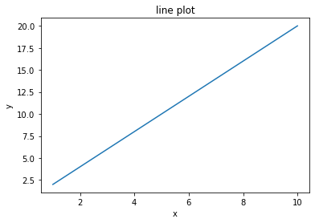

```python
plt.plot(x, y)
plt.title('line plot')
plt.xlabel('x')
plt.ylabel('y')
plt.show()
```

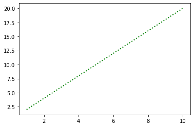

```python
# changing line aesthetics
plt.plot(x, y, color='g', linestyle=':', linewidth=2)
plt.show()
```

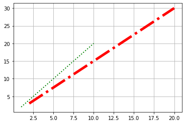

```python
# adding two lines in the same plot
y1 = 2 * x
y2 = 3 * x
plt.plot(x, y, color='g', linestyle=':', linewidth=2)
plt.plot(y1, y2, color='r', linestyle='-.', linewidth=5)
plt.grid(True)
# plt.show()
```

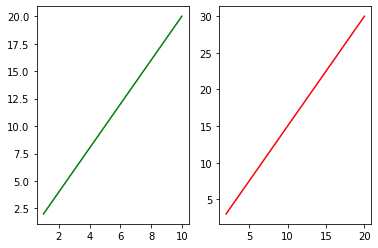

```python
# Adding sub-plots
x = np.arange(1, 11)
y1 = 2 * x
y2 = 3 * x

plt.subplot(1, 2, 1) # (1, 2, 1) : 1 row 2 column and last 1 means first plot figure.
plt.plot(x, y, color='g', linestyle='-')

plt.subplot(1,2,2) # 1 row , 2 col and 2 subplot fig (matrix stuff).
plt.plot(y1, y2, color='r')
plt.show()
```

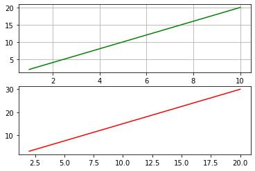

```python
# Adding sub-plots
x = np.arange(1, 11)
y1 = 2 * x
y2 = 3 * x

plt.subplot(2, 1, 1) # 2 row, 1, col , 1 sub plot
plt.plot(x, y, color='g', linestyle='-')
plt.grid(True)

plt.subplot(2, 1, 2) # 2 row, 1 col , 2 sub plot.
plt.plot(y1, y2, color='r')
# plt.grid(True)
plt.show()
```

```python
students = {'bob': 87, 'matt': 56, 'sam': 27}
students
```

```
{'bob': 87, 'matt': 56, 'sam': 27}
```

```python
names = list(students.keys())
values = list(students.values())
print(names,'\n', values)
```

```
['bob', 'matt', 'sam']
 [87, 56, 27]
```

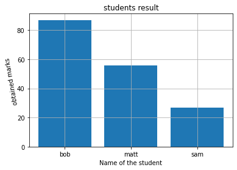

```python
plt.bar(names, values)
plt.xlabel('Name of the student')
plt.ylabel('obtained marks', rotation=100)
plt.title('students result')
plt.grid(True)
plt.show()
```

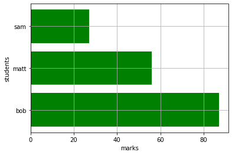

```python
# Horizontal bar plot
plt.barh(names, values, color='g')
plt.xlabel('marks')
plt.ylabel('students')
plt.grid(True)
plt.show()
```

```python
# basic scatter-plot
x = range(10, 91, 10)
a = [8, 1, 7, 2, 0, 3, 7, 3, 2]
```

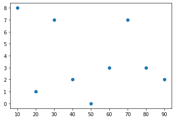

```python
plt.scatter(x, a)
```

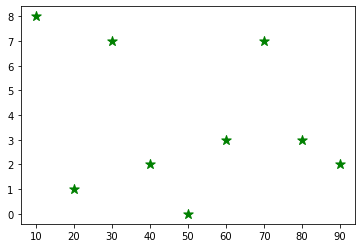

```python
plt.scatter(x, a, marker='*', c='g', s=100) # s attribute is marker size.
```

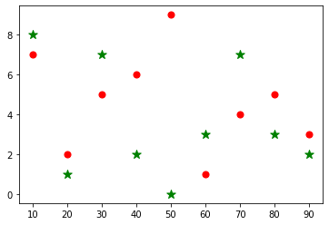

```python
# adding two markers in the same plot
b = [7, 2, 5, 6, 9, 1, 4, 5, 3]
plt.scatter(x, a, marker='*', c='g', s=100)
plt.scatter(x, b, marker='.', c='r', s=200)
plt.show()
```

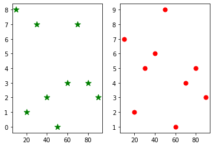

```python
# adding subplot
plt.subplot(1, 2, 1)
plt.scatter(x, a, marker='*', c='g', s=100)

plt.subplot(1, 2, 2)
plt.scatter(x, b, marker='.', c='r', s=200)

plt.show()
```

```python
# histogram
data = [1, 3, 3, 3, 3, 9, 9, 5, 4, 4, 8, 8, 8, 6, 7]
```

```python
data
```

```
[1, 3, 3, 3, 3, 9, 9, 5, 4, 4, 8, 8, 8, 6, 7]
```

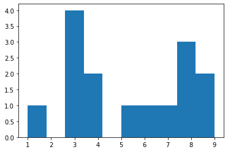

```python
#making histogram: for numerical values.
plt.hist(data)
plt.show()
```

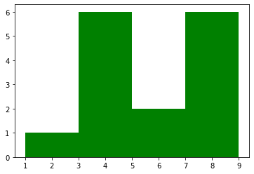

```python
# changing aesthetics
plt.hist(data, color='g', bins=4)
```

```python
# working with dataset
df
```

|  | Id | SepalLengthCm | SepalWidthCm | PetalLengthCm | PetalWidthCm | Species |
| --- | --- | --- | --- | --- | --- | --- |
| 0 | 1 | 5.1 | 3.5 | 1.4 | 0.2 | Iris-setosa |
| 1 | 2 | 4.9 | 3.0 | 1.4 | 0.2 | Iris-setosa |
| 2 | 3 | 4.7 | 3.2 | 1.3 | 0.2 | Iris-setosa |
| 3 | 4 | 4.6 | 3.1 | 1.5 | 0.2 | Iris-setosa |
| 4 | 5 | 5.0 | 3.6 | 1.4 | 0.2 | Iris-setosa |
| ... | ... | ... | ... | ... | ... | ... |
| 145 | 146 | 6.7 | 3.0 | 5.2 | 2.3 | Iris-virginica |
| 146 | 147 | 6.3 | 2.5 | 5.0 | 1.9 | Iris-virginica |
| 147 | 148 | 6.5 | 3.0 | 5.2 | 2.0 | Iris-virginica |
| 148 | 149 | 6.2 | 3.4 | 5.4 | 2.3 | Iris-virginica |
| 149 | 150 | 5.9 | 3.0 | 5.1 | 1.8 | Iris-virginica |

150 rows × 6 columns

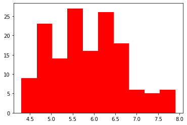

```python
plt.hist(df['SepalLengthCm'], color='r')
```

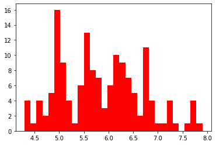

```python
plt.hist(df['SepalLengthCm'], bins=30, color='r')
plt.show()
```

### Box plot

- sometimes boxplots are called "box and whisker" plots
- line in the box is the median, 50% of the data is above the median, and 50% of the data is below the median.
- within the box itself, we have 25% of the data above teh median, and 25% of the data below the median. so 50% data within the box.

```python
one = range(1, 10)
two = [1, 2, 3, 4, 5, 4, 3, 2, 1]
three = [6, 7, 8, 9, 8, 7, 6, 5, 4]
data = list([one, two , three])
```

```python
data
```

```
[range(1, 10), [1, 2, 3, 4, 5, 4, 3, 2, 1], [6, 7, 8, 9, 8, 7, 6, 5, 4]]
```

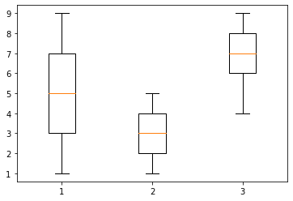

```python
plt.boxplot(data)
plt.show()
```

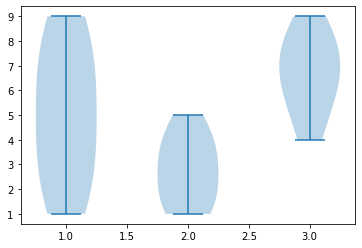

```python
# violin-plot
plt.violinplot(data)
plt.show()
```

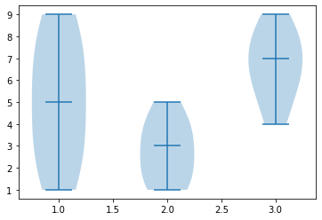

```python
plt.violinplot(data, showmedians=True)
plt.show()
```

```python
# Pie-Chart
# distribution between different categorical values.
fruit = ['Apple', 'Orange', 'Mango', 'Guava']
quantity = [67, 34, 100, 29]
```

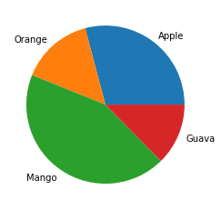

```python
plt.pie(quantity, labels=fruit)
plt.show()
```

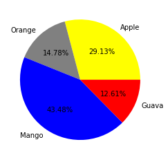

```python
# percentage in pie-char: use autopct
# %0.2f%%: means 2 digits after decimal.
plt.pie(quantity, labels=fruit, autopct='%0.2f%%',
       colors=['yellow', 'grey', 'blue', 'red'])
plt.show()
```

### DoughNut-Char

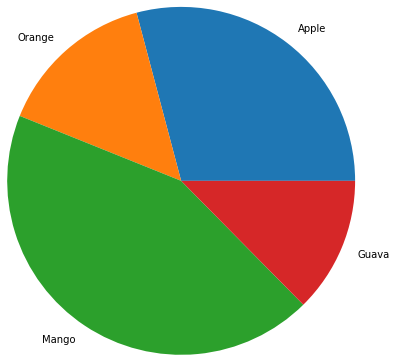

```python
plt.pie(quantity, labels=fruit, radius=2)
plt.show()
```

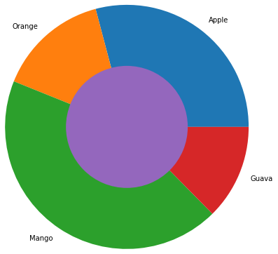

```python
plt.pie(quantity, labels=fruit, radius=2)
plt.pie([1])
plt.show()
```

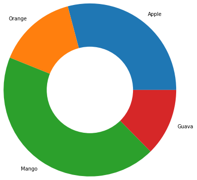

```python
plt.pie(quantity, labels=fruit, radius=2)
plt.pie([1], colors=['w'])
plt.show()
```

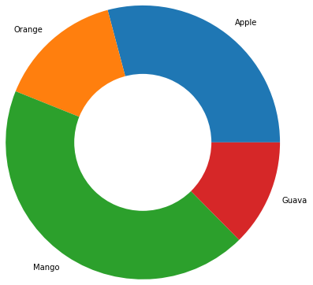

```python
plt.pie(quantity, labels=fruit, radius=2)
plt.pie([1], colors=['w'], radius=1) #inner circle radius
plt.show()
```

# EDA IPL DATASET

### objective:

- find out the most successful teams, players and factors contributing win or loss of a team.

```python
import numpy as np
import pandas as pd
import seaborn as sns
import matplotlib.pyplot as plt
```

```python
ipl = pd.read_csv('matches.csv')
```

```python
# data informatoin
print(ipl.info())
```

```
<class 'pandas.core.frame.DataFrame'>
RangeIndex: 636 entries, 0 to 635
Data columns (total 18 columns):
 #   Column           Non-Null Count  Dtype
---  ------           --------------  -----
 0   id               636 non-null    int64
 1   season           636 non-null    int64
 2   city             629 non-null    object
 3   date             636 non-null    object
 4   team1            636 non-null    object
 5   team2            636 non-null    object
 6   toss_winner      636 non-null    object
 7   toss_decision    636 non-null    object
 8   result           636 non-null    object
 9   dl_applied       636 non-null    int64
 10  winner           633 non-null    object
 11  win_by_runs      636 non-null    int64
 12  win_by_wickets   636 non-null    int64
 13  player_of_match  633 non-null    object
 14  venue            636 non-null    object
 15  umpire1          635 non-null    object
 16  umpire2          635 non-null    object
 17  umpire3          0 non-null      float64
dtypes: float64(1), int64(5), object(12)
memory usage: 89.6+ KB
None
```

```python
ipl.head()
```

|  | id | season | city | date | team1 | team2 | toss_winner | toss_decision | result | dl_applied | winner | win_by_runs | win_by_wickets | player_of_match | venue | umpire1 | umpire2 | umpire3 |
| --- | --- | --- | --- | --- | --- | --- | --- | --- | --- | --- | --- | --- | --- | --- | --- | --- | --- | --- |
| 0 | 1 | 2017 | Hyderabad | 2017-04-05 | Sunrisers Hyderabad | Royal Challengers Bangalore | Royal Challengers Bangalore | field | normal | 0 | Sunrisers Hyderabad | 35 | 0 | Yuvraj Singh | Rajiv Gandhi International Stadium, Uppal | AY Dandekar | NJ Llong | NaN |
| 1 | 2 | 2017 | Pune | 2017-04-06 | Mumbai Indians | Rising Pune Supergiant | Rising Pune Supergiant | field | normal | 0 | Rising Pune Supergiant | 0 | 7 | SPD Smith | Maharashtra Cricket Association Stadium | A Nand Kishore | S Ravi | NaN |
| 2 | 3 | 2017 | Rajkot | 2017-04-07 | Gujarat Lions | Kolkata Knight Riders | Kolkata Knight Riders | field | normal | 0 | Kolkata Knight Riders | 0 | 10 | CA Lynn | Saurashtra Cricket Association Stadium | Nitin Menon | CK Nandan | NaN |
| 3 | 4 | 2017 | Indore | 2017-04-08 | Rising Pune Supergiant | Kings XI Punjab | Kings XI Punjab | field | normal | 0 | Kings XI Punjab | 0 | 6 | GJ Maxwell | Holkar Cricket Stadium | AK Chaudhary | C Shamshuddin | NaN |
| 4 | 5 | 2017 | Bangalore | 2017-04-08 | Royal Challengers Bangalore | Delhi Daredevils | Royal Challengers Bangalore | bat | normal | 0 | Royal Challengers Bangalore | 15 | 0 | KM Jadhav | M Chinnaswamy Stadium | NaN | NaN | NaN |

```python
# season we have got in the dataste
ipl['season'].unique()
```

```
array([2017, 2008, 2009, 2010, 2011, 2012, 2013, 2014, 2015, 2016])
```

- dl_applied:
- The Duckworth–Lewis–Stern method (DLS) is a mathematical formulation designed to calculate the target score (number of runs needed to win) for the team batting second in a limited overs cricket match interrupted by weather or other circumstances.
- The method was devised by two English statisticians, Frank Duckworth and Tony Lewis, and was formerly known as the Duckworth–Lewis method (D/L)
- **win by wickets**: won by seocond batting
- **win by runs**: won by first batting

```python
ipl.shape
```

```
(636, 18)
```

```python
# getting the frequency of most man of the match awards
ipl['player_of_match'].value_counts()
```

```
CH Gayle          18
YK Pathan         16
DA Warner         15
AB de Villiers    15
RG Sharma         14
                  ..
AD Mathews         1
LR Shukla          1
R Bhatia           1
A Singh            1
BCJ Cutting        1
Name: player_of_match, Length: 201, dtype: int64
```

```python
# getting the top 10 players with most man of the match award.
ipl['player_of_match'].value_counts()[:10]
```

```
CH Gayle          18
YK Pathan         16
DA Warner         15
AB de Villiers    15
RG Sharma         14
SK Raina          14
MS Dhoni          13
G Gambhir         13
AM Rahane         12
MEK Hussey        12
Name: player_of_match, dtype: int64
```

```python
# getting names of top 5 man of the match award
for index, i in enumerate(ipl['player_of_match'].value_counts()[:5].keys(), 1):
    print(index, i)
```

```
1 CH Gayle
2 YK Pathan
3 DA Warner
4 AB de Villiers
5 RG Sharma
```

```python
names = list(ipl['player_of_match'].value_counts()[:5].keys())
print(type(names), names)
```

```
<class 'list'> ['CH Gayle', 'YK Pathan', 'DA Warner', 'AB de Villiers', 'RG Sharma']
```

```python
values = ipl['player_of_match'].value_counts()[:5]
print(values)
print('first value: ', values[0])
```

```
CH Gayle          18
YK Pathan         16
DA Warner         15
AB de Villiers    15
RG Sharma         14
Name: player_of_match, dtype: int64
first value:  18
```

```
<BarContainer object of 5 artists>
```

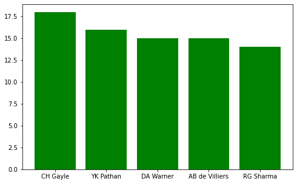

```python
plt.figure(figsize=(8,5))
plt.bar(names, values, color='g')
```

```python
# getting the frequency of result column
ipl['result'].value_counts()
# no result: match was not occured because of some reason.
```

```
normal       626
tie            7
no result      3
Name: result, dtype: int64
```

```python
# finding out the number of toss wins by each team
ipl['toss_winner'].value_counts()
```

```
Mumbai Indians                 85
Kolkata Knight Riders          78
Delhi Daredevils               72
Royal Challengers Bangalore    70
Kings XI Punjab                68
Chennai Super Kings            66
Rajasthan Royals               63
Deccan Chargers                43
Sunrisers Hyderabad            35
Pune Warriors                  20
Gujarat Lions                  15
Kochi Tuskers Kerala            8
Rising Pune Supergiants         7
Rising Pune Supergiant          6
Name: toss_winner, dtype: int64
```

```python
len(ipl[ipl['team2'] == 'Mumbai Indians'] ) + len(ipl[ipl['team2'] == 'Mumbai Indians'])
```

```
150
```

```python
# Extracting the records where a team won batting first
batting_first = ipl[ipl['win_by_runs']!=0]
batting_first.head()
```

|  | id | season | city | date | team1 | team2 | toss_winner | toss_decision | result | dl_applied | winner | win_by_runs | win_by_wickets | player_of_match | venue | umpire1 | umpire2 | umpire3 |
| --- | --- | --- | --- | --- | --- | --- | --- | --- | --- | --- | --- | --- | --- | --- | --- | --- | --- | --- |
| 0 | 1 | 2017 | Hyderabad | 2017-04-05 | Sunrisers Hyderabad | Royal Challengers Bangalore | Royal Challengers Bangalore | field | normal | 0 | Sunrisers Hyderabad | 35 | 0 | Yuvraj Singh | Rajiv Gandhi International Stadium, Uppal | AY Dandekar | NJ Llong | NaN |
| 4 | 5 | 2017 | Bangalore | 2017-04-08 | Royal Challengers Bangalore | Delhi Daredevils | Royal Challengers Bangalore | bat | normal | 0 | Royal Challengers Bangalore | 15 | 0 | KM Jadhav | M Chinnaswamy Stadium | NaN | NaN | NaN |
| 8 | 9 | 2017 | Pune | 2017-04-11 | Delhi Daredevils | Rising Pune Supergiant | Rising Pune Supergiant | field | normal | 0 | Delhi Daredevils | 97 | 0 | SV Samson | Maharashtra Cricket Association Stadium | AY Dandekar | S Ravi | NaN |
| 13 | 14 | 2017 | Kolkata | 2017-04-15 | Kolkata Knight Riders | Sunrisers Hyderabad | Sunrisers Hyderabad | field | normal | 0 | Kolkata Knight Riders | 17 | 0 | RV Uthappa | Eden Gardens | AY Dandekar | NJ Llong | NaN |
| 14 | 15 | 2017 | Delhi | 2017-04-15 | Delhi Daredevils | Kings XI Punjab | Delhi Daredevils | bat | normal | 0 | Delhi Daredevils | 51 | 0 | CJ Anderson | Feroz Shah Kotla | YC Barde | Nitin Menon | NaN |

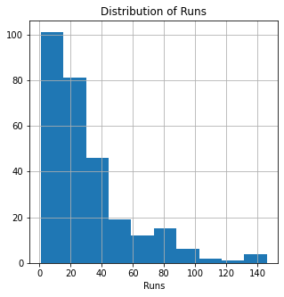

```python
plt.figure(figsize=(5, 5))
plt.hist(batting_first['win_by_runs'])
plt.title('Distribution of Runs')
plt.xlabel('Runs')
plt.grid()
plt.show()
```

```python
# which team won many times by doing batting first
batting_first['winner'].value_counts()
```

```
Mumbai Indians                 47
Chennai Super Kings            46
Kings XI Punjab                32
Kolkata Knight Riders          31
Royal Challengers Bangalore    30
Sunrisers Hyderabad            23
Rajasthan Royals               23
Delhi Daredevils               21
Deccan Chargers                18
Pune Warriors                   6
Rising Pune Supergiant          5
Kochi Tuskers Kerala            2
Rising Pune Supergiants         2
Gujarat Lions                   1
Name: winner, dtype: int64
```

```python
# making a bar-olot ; team won many times by doing batting first
team_name = list(batting_first['winner'].value_counts()[:3].keys())
team_name
```

```
['Mumbai Indians', 'Chennai Super Kings', 'Kings XI Punjab']
```

```python
runs = list(batting_first['winner'].value_counts()[:3])
print(runs)
```

```
[47, 46, 32]
```

```
<BarContainer object of 3 artists>
```

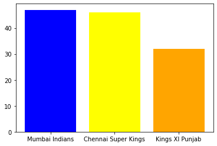

```python
plt.bar(team_name, runs, color=['blue', 'yellow', 'orange'])
```

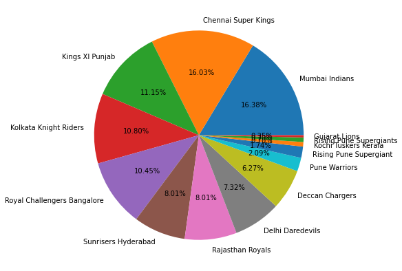

```python
# win percentage distrbution: highest.
plt.figure(figsize=(7,7))
plt.pie(list(batting_first['winner'].value_counts()), labels=list(batting_first['winner'].value_counts().keys()), autopct='%0.2f%%')
plt.show()
# pie char: first parameter: numerical, second: categorical.
```

```python
# number of matches played each season
ipl['season'].value_counts() #.sort_values()
```

```
2013    76
2012    74
2011    73
2010    60
2014    60
2016    60
2017    59
2015    59
2008    58
2009    57
Name: season, dtype: int64
```

```python
# number of matches played in each city
ipl['city'].value_counts()
```

```
Mumbai            85
Bangalore         66
Kolkata           61
Delhi             60
Hyderabad         49
Chennai           48
Chandigarh        46
Jaipur            33
Pune              32
Durban            15
Ahmedabad         12
Centurion         12
Visakhapatnam     11
Rajkot            10
Dharamsala         9
Johannesburg       8
Cape Town          7
Abu Dhabi          7
Ranchi             7
Port Elizabeth     7
Cuttack            7
Raipur             6
Sharjah            6
Kochi              5
Indore             5
Kanpur             4
Nagpur             3
Kimberley          3
East London        3
Bloemfontein       2
Name: city, dtype: int64
```

```python
# finding out how many times a team has won the match after wining the toss.
np.sum(ipl['toss_winner'] == ipl['winner'])
```

```
325
```

```python
ipl['toss_winner'].head() == ipl['winner'].head()
```

```
0    False
1     True
2     True
3     True
4     True
dtype: bool
```

```python
sum([True, True, False])
```

```
2
```

```python
ipl.shape
```

```
(636, 18)
```

```python
325/ipl.shape[0]
# 51 percent chance of win for the team who won the toss.
```

```
0.5110062893081762
```